# Final Project

Lakshya Mohan Rastogi Rakshit Dongre Yuv Boghani

2025-05-01

## Front Matter

```r
library(dplyr)
library(tidyverse)
```

```r
library(ggplot2)
library(fuzzyjoin)
```

# Task 1

### Research Question: Which maps are the most likely to win the map vote when they are an option?

Notes: To answer this question, write a paragraph (or more) discussing how you plan to answer this question. Be sure to address the data quality issues mentioned below and discuss how you will do the calculations. Then, write code and answer the question. (If I must answer questions about your approach/decision making process by reading your code rather than your discussion, you will lose points.) As part of your solution, you should calculate the proportion/probability that a map wins the vote given that it was a candidate. To do this, you will have to calculate the number times that each map was listed as a candidate (Map1 or Map2) and earned more votes than the other candidate. As part of this, you should consider whether a given map won the vote by getting more votes than the other option or if it was selected since it was `Map1` and the vote was a tie. You should also include a visualization of the results. There might be some data quality issues (such as misspelled map names and extra (trailing) blanks in some entries) to solve for this problem. You can find the proper names/spellings in the CODMaps.csv file. To full receive full credit, you must write code to solve these issues rather than editing the .csv files.

## Task 1 Code

### Loading the data from the CSV to DataFrames and making the data consistent

```r
mapsDF <- read.csv("~/Downloads/CODMaps.csv")
gmDF <- read.csv("~/Downloads/CODGameModes.csv")
votesDF1 <- read.csv("~/Downloads/CODGames_p1_380.csv")
votesDF2 <- read.csv("~/Downloads/CODGames_p2_380.csv")

# Combining the two dataframes into 1
votesDF <- bind_rows(votesDF1, votesDF2)

# Cleaning data, by converting it to lower case and then getting rid of any white spaces/blanks
votesDF$Map1 <- trimws(tolower(votesDF$Map1))
votesDF$Map2 <- trimws(tolower(votesDF$Map2))
votesDF$Choice <- trimws(tolower(votesDF$Choice))
mapsDF$Name <- trimws(tolower(mapsDF$Name))
```

### Checking for any mispelled data entries in any of the columns

```r
# Creating reference list of correct map names
referenceMaps <- mapsDF$Name

# Identifying maps not found in the reference list due to spelling mistakes
invalidMap1 <- votesDF$Map1[!(votesDF$Map1 %in% referenceMaps)]
invalidMap2 <- votesDF$Map2[!(votesDF$Map2 %in% referenceMaps)]
invalidChoice <- votesDF$Choice[!(votesDF$Choice %in% referenceMaps)]

# Displaying incorrect entries in column 'Map1', 'Map2', and 'Choice'
print("Maps in 'Map1' that do not match reference list:")
```

```
## [1] "Maps in 'Map1' that do not match reference list:"
```

```r
print(unique(invalidMap1))
```

```
## [1] ""                  "ruah"              "collateral"
## [4] "riad"              "collateral striek" "miami stirke"
## [7] "collaterol strike" "deprogam"
```

```r
print("Maps in 'Map2' that do not match reference list:")
```

```
## [1] "Maps in 'Map2' that do not match reference list:"
```

```r
print(unique(invalidMap2))
```

```
## [1] ""                       "miami stirke"           "collateral"
## [4] "nuketown '84 halloween" "miami sstrike"          "amrada strike"
```

```r
print("Maps in 'Choice' that do not match reference list:")
```

```
## [1] "Maps in 'Choice' that do not match reference list:"
```

```r
print(unique(invalidChoice))
```

```
## [1] ""                       "apocolypse"             "collateral"
## [4] "collaterel strike"      "nuketown '84 halloween" "deisel"
## [7] "riad"
```

### Doing Fuzzy matching to fix small spelling errors as seen above

```r
# Function to fuzzy match ONLY incorrect names
correct_map_name <- function(map_name, reference_list) {
  if (is.na(map_name) || map_name == "") {
    return(map_name)  # Keep blanks as they are
  }

  if (map_name %in% reference_list) {
    return(map_name)  # If already correct, keep as is
  }

  # Find closest match using Levenshtein distance
  best_match <- reference_list[which.min(stringdist::stringdist(map_name, reference_list))]
  return(best_match)
}

# Reference list from mapsDF
reference_maps <- mapsDF$Name

# Apply fuzzy correction ONLY to incorrect entries
votesDF <- votesDF %>%
  mutate(
    Map1 = sapply(Map1, correct_map_name, reference_maps),
    Map2 = sapply(Map2, correct_map_name, reference_maps),
    Choice = sapply(Choice, correct_map_name, reference_maps)
  )
```

## Counting odds to see which map will be chosen if available

### Removing all invalid entries

```r
votesDFiltered <- votesDF %>% filter(!is.na(Map1) & Map1 != "" &
                                     !is.na(Map2) & Map2 != "" &
                                     !is.na(Choice) & Choice != "")

print(head(votesDFiltered))
```

```
##                Map1         Map2            Choice MapVote   Date FullPartial
## 1            moscow miami strike      miami strike  5 to 0 6/6/22        Full
## 2            moscow          wmd            moscow  2 to 0 6/6/22        Full
## 3          drive-in       jungle          drive-in  2 to 0 6/6/22        Full
## 4 collateral strike     hijacked collateral strike  3 to 3 6/6/22        Full
## 5 crossroads strike         raid              raid  4 to 3 6/6/22        Full
## 6         the pines     standoff          standoff  5 to 1 6/6/22        Full
##   Result Eliminations Deaths Score Damage TotalXP PrimaryWeapon          XPType
## 1 100-97           22     17  4070    634   11002           M16       10% Boost
## 2  76-89           20     15  5305    560    9451           M16       10% Boost
## 3 80-100           10     19  2170    280   11502           M16 Double XP + 10%
## 4 71-100           11     19  2195    308   11133           M16 Double XP + 10%
## 5 85-100            7     18   850    196   10077           M16 Double XP + 10%
## 6 100-70           18     14  3505    504   16703           M16 Double XP + 10%
##   DidPlayerVote GameType Confirms Denies Objectives ObjectiveKills Captures
## 1            No HC - TDM       NA     NA         NA             NA       NA
## 2            No HC - TDM       NA     NA         NA             NA       NA
## 3            No HC - TDM       NA     NA         NA             NA       NA
## 4            No HC - TDM       NA     NA         NA             NA       NA
## 5            No HC - TDM       NA     NA         NA             NA       NA
## 6            No HC - TDM       NA     NA         NA             NA       NA
##   Diffuses Plants Detonates Deposits Time_Sec Time_Min
## 1       NA     NA        NA       NA       NA       NA
## 2       NA     NA        NA       NA       NA       NA
## 3       NA     NA        NA       NA       NA       NA
## 4       NA     NA        NA       NA       NA       NA
## 5       NA     NA        NA       NA       NA       NA
## 6       NA     NA        NA       NA       NA       NA
```

### Counting all appearances of each map in column ‘Map1’

```r
map1Counts <- votesDFiltered %>% count(Map1, sort = TRUE, name = "Count1")
map1Counts <-  map1Counts %>% rename(Map = Map1)

print("Counts of maps appearing in the Map1 column:")
```

```
## [1] "Counts of maps appearing in the Map1 column:"
```

```r
print(map1Counts)
```

```
##                  Map Count1
## 1             moscow     46
## 2          the pines     42
## 3         apocalypse     36
## 4          checkmate     34
## 5             cartel     32
## 6            express     32
## 7           yamantau     31
## 8             diesel     29
## 9       miami strike     27
## 10               zoo     26
## 11           echelon     25
## 12          garrison     25
## 13 collateral strike     24
## 14 crossroads strike     24
## 15          drive-in     24
## 16     armada strike     23
## 17          hijacked     22
## 18             slums     22
## 19          standoff     22
## 20              rush     20
## 21      nuketown '84     19
## 22              raid     19
## 23         satellite     17
## 24         deprogram     14
## 25           amerika     11
## 26             miami     11
## 27            jungle     10
## 28               wmd      7
```

### Counting all appearances of each map in column ‘Map2’

```r
map2Counts <- votesDFiltered %>% count(Map2, sort = TRUE, name = "Count2")
map2Counts <-  map2Counts %>% rename(Map = Map2)

print("Counts of maps appearing in the Map2 column:")
```

```
## [1] "Counts of maps appearing in the Map2 column:"
```

```r
print(map2Counts)
```

```
##                  Map Count2
## 1             cartel     40
## 2           yamantau     38
## 3  crossroads strike     34
## 4       miami strike     32
## 5            express     30
## 6  collateral strike     29
## 7         apocalypse     27
## 8          deprogram     27
## 9           garrison     27
## 10          hijacked     27
## 11            moscow     27
## 12            diesel     26
## 13              rush     26
## 14              raid     25
## 15          standoff     25
## 16         the pines     24
## 17               zoo     24
## 18     armada strike     22
## 19         satellite     22
## 20         checkmate     21
## 21      nuketown '84     21
## 22           echelon     20
## 23          drive-in     19
## 24             slums     19
## 25           amerika     16
## 26             miami     14
## 27               wmd      8
## 28            jungle      4
```

### Calculating total appearances

```r
totalCounts <- full_join(map1Counts, map2Counts, by = "Map") %>%
  mutate( Count1 = replace_na(Count1, 0),
          Count2 = replace_na(Count2, 0)
          ) %>%
  mutate( totalAppearances = Count1 + Count2) %>%
  select (Map, totalAppearances) %>%
  arrange(desc(totalAppearances))

print("Total appearances count for each map (Map1 + Map2):")
```

```
## [1] "Total appearances count for each map (Map1 + Map2):"
```

```r
print(totalCounts)
```

```
##                  Map totalAppearances
## 1             moscow               73
## 2             cartel               72
## 3           yamantau               69
## 4          the pines               66
## 5         apocalypse               63
## 6            express               62
## 7       miami strike               59
## 8  crossroads strike               58
## 9          checkmate               55
## 10            diesel               55
## 11 collateral strike               53
## 12          garrison               52
## 13               zoo               50
## 14          hijacked               49
## 15          standoff               47
## 16              rush               46
## 17           echelon               45
## 18     armada strike               45
## 19              raid               44
## 20          drive-in               43
## 21             slums               41
## 22         deprogram               41
## 23      nuketown '84               40
## 24         satellite               39
## 25           amerika               27
## 26             miami               25
## 27               wmd               15
## 28            jungle               14
```

### Helper function to count votes for Map selection

```r
parseVotes <- function(voteString) {
  # Return NA for missing values
  if (is.na(voteString) || voteString == "") {
    return(c(NA, NA))
  }

  # Try different possible formats
  if (grepl(" to ", voteString, ignore.case = TRUE)) {
    # Format: "3 to 2"
    pattern <- " to "
  } else if (grepl("-", voteString)) {
    # Format: "3-2"
    pattern <- "-"
  } else {
    # No recognized pattern
    return(c(NA, NA))
  }

  # Split the string by the identified pattern
  votes <- tryCatch({
    parts <- strsplit(voteString, pattern, fixed = TRUE)[[1]]
    as.numeric(trimws(parts))
  }, warning = function(w) {
    c(NA, NA)
  }, error = function(e) {
    c(NA, NA)
  })

  # Check if we have exactly two valid numbers
  if (length(votes) == 2 && all(!is.na(votes))) {
    return(votes)
  } else {
    return(c(NA, NA))
  }
}
```

### Counting wins for each map

```r
votesDFilteredWithTies <- votesDFiltered %>%
  mutate(voteCounts = lapply(MapVote, parseVotes),
         vote1 = sapply(voteCounts, `[`, 1),
         vote2 = sapply(voteCounts, `[`, 2),
         isTie = ifelse(!is.na(vote1) & !is.na(vote2) & vote1 == vote2, TRUE, FALSE))


winCounts <- votesDFilteredWithTies %>%
  mutate(winningMap = case_when(
    isTie == TRUE ~ Map1,
    TRUE ~ Choice)
  ) %>%
  group_by(winningMap) %>%
  summarise(Wins = n(), .groups = 'drop') %>%
  rename(Map = winningMap) %>%
  arrange(desc(Wins))

tieCounts <- votesDFilteredWithTies %>%
  filter(isTie == TRUE) %>%
  group_by(Map1) %>%
  summarise(TieWins = n(), .groups = 'drop') %>%
  rename(Map = Map1)

print(winCounts)
```

```
## # A tibble: 28 × 2
##    Map                Wins
##    <chr>             <int>
##  1 crossroads strike    45
##  2 diesel               39
##  3 express              39
##  4 checkmate            34
##  5 raid                 34
##  6 nuketown '84         33
##  7 standoff             33
##  8 yamantau             33
##  9 moscow               32
## 10 collateral strike    31
## # ℹ 18 more rows
```

# Calculating Win Probability

```r
winProb <- totalCounts %>%
  left_join(winCounts, by = "Map") %>%
  left_join(tieCounts, by = "Map") %>%
  # Replace NA values with 0
  mutate(Wins = ifelse(is.na(Wins), 0, Wins),
         TieWins = ifelse(is.na(TieWins), 0, TieWins)) %>%
  # Calculate probabilities
  mutate(
    WinProbability = ifelse(totalAppearances > 0, Wins / totalAppearances, 0),
    TieWinProbability = ifelse(totalAppearances > 0, TieWins / totalAppearances, 0)
  ) %>%
  # Select the relevant columns
  select(Map, totalAppearances, Wins, TieWins, WinProbability, TieWinProbability) %>%
  # Arrange by win probability, descending
  arrange(desc(WinProbability))


print(winProb)
```

```
##                  Map totalAppearances Wins TieWins WinProbability
## 1       nuketown '84               40   33       5      0.8250000
## 2  crossroads strike               58   45       4      0.7758621
## 3               raid               44   34       2      0.7727273
## 4             diesel               55   39       1      0.7090909
## 5           standoff               47   33       3      0.7021277
## 6              slums               41   27       4      0.6585366
## 7            express               62   39       5      0.6290323
## 8          checkmate               55   34       5      0.6181818
## 9  collateral strike               53   31       4      0.5849057
## 10          drive-in               43   25       3      0.5813953
## 11              rush               46   24       2      0.5217391
## 12           amerika               27   14       1      0.5185185
## 13          hijacked               49   25       3      0.5102041
## 14               zoo               50   25       7      0.5000000
```

[output cut: 43 more lines]

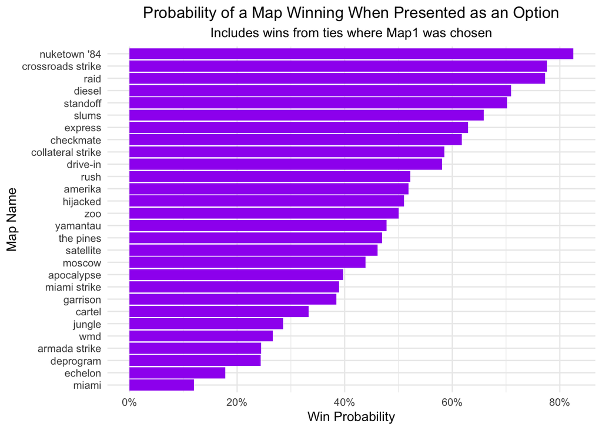

```r
#Visualization for win probabilities
winProbPlot <- ggplot(winProb, aes(x = reorder(Map, WinProbability), y = WinProbability)) +
  geom_bar(stat = "identity", fill = "purple") +
  coord_flip() +
  scale_y_continuous(labels = scales::percent_format(accuracy = 1)) +
  labs(
    title = "Probability of a Map Winning When Presented as an Option",
    subtitle = "Includes wins from ties where Map1 was chosen",
    x = "Map Name",
    y = "Win Probability"
  ) +
  theme_minimal() +
  theme(plot.title = element_text(hjust = 0.5),
        plot.subtitle = element_text(hjust = 0.5))
print(winProbPlot)
```

## Discussion of Task 1 Approach and Answer for Research Question

So we can see from the approach we have taken to the code for Task 1 in answering the question and its results that the map most likely to win a vote when an option is ’ Nuketown ‘84’, with a whopping 82.5% chance of winning when it is presented as an option. It is followed by ‘Crossroads Strike’ and ‘Raid’.

# Task 2

Repeat Task 1 using a generative AI of your choice. To answer this question, mention the tool (including version number if appropriate) you have selected. Then, discuss the prompt(s) you have used and provide the solution produced by the generative AI. While it is fine to paste the question into the generative AI as your first prompt, you should also use additional follow-up prompts if it is beneficial to do so. Be sure to discuss all prompts used in your report.

Then, implement the generative AI solution.

Finally, and most importantly, you should compare your solution from Task 1 to the generative AI solution. Discuss similarities/differences, strengths/weaknesses, etc., and provide an overall assessment of which solution is better. The discussion should consider the correctness of the answers and should be substantial. Demonstrate that you have given the comparison considerable thought by making at least 3 substantial points as part of your comparison. Each point should take the form of a well-written paragraph.

## Approach

We used Claude 3.7 Sonnet as the model to answer this Task and to generate its code.

This was the prompt I gave it:

“Hey I need you to solve this problem:

Task 1 (Data Cleaning and Data Visualization – Complete without Generative AI): Relevant Information: (Complete without using Generative AI) Prior to each online match, players in the game lobby are presented with two options for the battlefield of the upcoming game (Map1 and Map2). The players have the option to vote and the resulting vote is recorded in the MapVote column. The winning map is listed in the Choice column. In the event of a tie vote, the map listed in Map1 is chosen. (Games for which the player entered the lobby after the vote has taken place have no information in Map1 and Map2 but have the winning map presented in Choice.)

Research Question: Which maps are the most likely to win the map vote when they are an option?

Notes: To answer this question, write a paragraph (or more) discussing how you plan to answer this question. Be sure to address the data quality issues mentioned below and discuss how you will do the calculations. Then, write code and answer the question. (If I must answer questions about your approach/decision making process by reading your code rather than your discussion, you will lose points.) As part of your solution, you should calculate the proportion/probability that a map wins the vote given that it was a candidate. To do this, you will have to calculate the number times that each map was listed as a candidate (Map1 or Map2) and earned more votes than the other candidate. As part of this, you should consider whether a given map won the vote by getting more votes than the other option or if it was selected since it was Map1 and the vote was a tie. You should also include a visualization of the results. There might be some data quality issues (such as misspelled map names and extra (trailing) blanks in some entries) to solve for this problem. You can find the proper names/spellings in the CODMaps.csv file. To full receive full credit, you must write code to solve these issues rather than editing the .csv files.

keep in mind that these are the columns available in the CODGames_p1_380 and CODGames_p2_380 CSV files:

Map1 Map2 Choice MapVote Date FullPartial Result Eliminations Deaths Score Damage TotalXP PrimaryWeapon XPType DidPlayerVote GameType Confirms Denies Objectives ObjectiveKills Captures Diffuses Plants Detonates Deposits Time_Sec Time_Min

Here are the columns availabe in the CODMaps csv file:

Name FirstAvailable Date

give me the full code in R for this keep in mind, you have to do data cleaning (fix spelling mistakes, get rid of invalid entries (such as empty values for columns Map1 and map2 or choice)) you also have to then find the win probability of the map if it is a choice accouintig for all the various factors mentioned in the above notes and amke sure that you do this across the CSVs (both of them)”

As you can see in this prompt I gave it the task 1 problem and then rpovided extra data and context with respect to the names of the CSV files, names of the columns, I also asked it to focus in the data pre-processing to make sure that the data has no errors in it. I also asked it to focus on the notes provided in Task 1 so it has all the nuances for the problem down.

## Task 2 Code

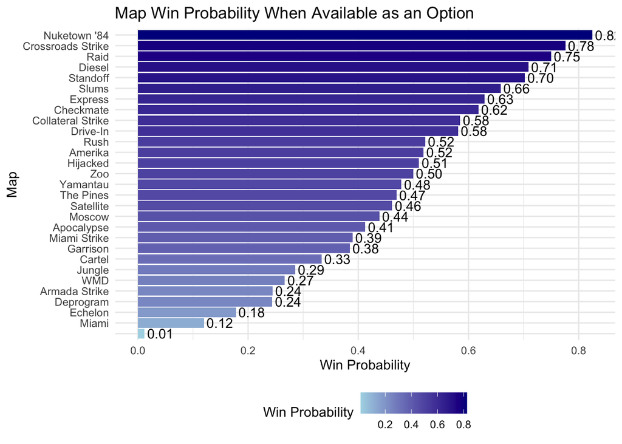

```r
# Load necessary libraries
library(dplyr)
library(tidyr)
library(stringr)
library(ggplot2)

# Read the CSV files
cod_games_p1 <- read.csv("~/Downloads/CODGames_p1_380.csv")
cod_games_p2 <- read.csv("~/Downloads/CODGames_p2_380.csv")
cod_maps <- read.csv("~/Downloads/CODMaps.csv")

# Combine the two game datasets
cod_games <- rbind(cod_games_p1, cod_games_p2)

# Clean map names by trimming whitespace
cod_games <- cod_games %>%
  mutate(
    Map1 = str_trim(Map1),
    Map2 = str_trim(Map2),
    Choice = str_trim(Choice)
  )

# Get the list of valid map names from CODMaps
valid_maps <- str_trim(cod_maps$Name)

# Function to correct map names based on similarity
correct_map_name <- function(map_name) {
  if (is.na(map_name) || map_name == "") {
    return(map_name)
  }

  # If already a valid map name, return as is
  if (map_name %in% valid_maps) {
    return(map_name)
  }

  # Find closest match
  best_match <- valid_maps[which.min(adist(map_name, valid_maps))]
  return(best_match)
}

# Apply correction to map names
cod_games <- cod_games %>%
  mutate(
    Map1 = sapply(Map1, correct_map_name),
    Map2 = sapply(Map2, correct_map_name),
    Choice = sapply(Choice, correct_map_name)
  )

# Filter out rows where Map1 and Map2 are both empty (player entered after vote)
cod_games_filtered <- cod_games %>%
  filter(!(is.na(Map1) & is.na(Map2)))

# Determine if a map won due to tie (Map1 is chosen in tie)
cod_games_filtered <- cod_games_filtered %>%
  mutate(
    MapVote = as.character(MapVote),
    WonDueToTie = ifelse(MapVote == "Tie" & Choice == Map1, TRUE, FALSE)
  )

# Create a long format dataset to calculate win rates
map_appearances <- cod_games_filtered %>%
  select(Map1, Map2, Choice, MapVote, WonDueToTie) %>%
  pivot_longer(
    cols = c(Map1, Map2),
    names_to = "Position",
    values_to = "Map"
  ) %>%
  filter(!is.na(Map)) %>%
  mutate(
    Won = Map == Choice,
    WonByVotes = Won & !WonDueToTie,
    WonByTie = Won & WonDueToTie
  )

# Calculate win probabilities for each map
map_win_stats <- map_appearances %>%
  group_by(Map) %>%
  summarize(
    TotalAppearances = n(),
    TotalWins = sum(Won),
    WonByVotes = sum(WonByVotes),
    WonByTie = sum(WonByTie),
    WinProbability = TotalWins / TotalAppearances,
    WinByVotesProbability = WonByVotes / TotalAppearances,
    WinByTieProbability = WonByTie / TotalAppearances
  ) %>%
  arrange(desc(WinProbability))

# Create visualization
ggplot(map_win_stats, aes(x = reorder(Map, WinProbability), y = WinProbability)) +
  geom_bar(stat = "identity", aes(fill = WinProbability)) +
  geom_text(aes(label = sprintf("%.2f", WinProbability)), hjust = -0.1) +
  scale_fill_gradient(low = "lightblue", high = "darkblue") +
  coord_flip() +
  labs(
    title = "Map Win Probability When Available as an Option",
    x = "Map",
    y = "Win Probability",
    fill = "Win Probability"
  ) +
  theme_minimal() +
  theme(legend.position = "bottom")
```

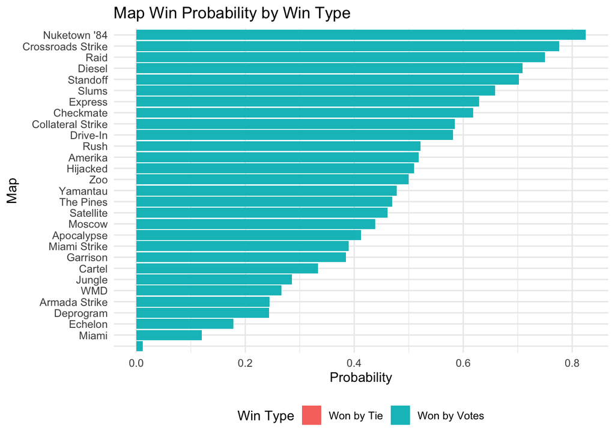

```r
# Create a stacked bar chart showing wins by votes vs. wins by tie
map_win_stats_long <- map_win_stats %>%
  select(Map, WinByVotesProbability, WinByTieProbability) %>%
  pivot_longer(
    cols = c(WinByVotesProbability, WinByTieProbability),
    names_to = "WinType",
    values_to = "Probability"
  ) %>%
  mutate(WinType = ifelse(WinType == "WinByVotesProbability", "Won by Votes", "Won by Tie"))

ggplot(map_win_stats_long, aes(x = reorder(Map, Probability, sum), y = Probability, fill = WinType)) +
  geom_bar(stat = "identity") +
  coord_flip() +
  labs(
    title = "Map Win Probability by Win Type",
    x = "Map",
    y = "Probability",
    fill = "Win Type"
  ) +
  theme_minimal() +
  theme(legend.position = "bottom")
```

```r
# Print the results
print(map_win_stats)
```

```
## # A tibble: 29 × 8
##    Map             TotalAppearances TotalWins WonByVotes WonByTie WinProbability
##    <chr>                      <int>     <int>      <int>    <int>          <dbl>
##  1 Nuketown '84                  40        33         33        0          0.825
##  2 Crossroads Str…               58        45         45        0          0.776
##  3 Raid                          44        33         33        0          0.75
##  4 Diesel                        55        39         39        0          0.709
##  5 Standoff                      47        33         33        0          0.702
##  6 Slums                         41        27         27        0          0.659
##  7 Express                       62        39         39        0          0.629
##  8 Checkmate                     55        34         34        0          0.618
##  9 Collateral Str…               53        31         31        0          0.585
## 10 Drive-In                      43        25         25        0          0.581
## # ℹ 19 more rows
## # ℹ 2 more variables: WinByVotesProbability <dbl>, WinByTieProbability <dbl>
```

## Comparison of Task 1 and Task 2 Code and Results

# Task 3

Relevant Information: There are a variety games types (GameType variable) within this dataset. The difference between the game types is that players have different objectives for the game. For instance, in the game type “Hardpoint”, teams earn points by capturing and defending a location. In “TDM” teams earn points by eliminating enemy opponents. As these game types have different objectives and may last for different amounts of time, the game type might affect the TotalXP earned.

## Research Question: How does the game type affect TotalXP after accounting for the Score?

Notes: Score refers to the player’s score, not the “score” of the match (i.e., not the Result column). This answer requires some data wrangling that may require knowledge that we have not covered. (Again, part of the skillset you are working to develop is learning how to answer questions you have not seen previously.) In particular, there is no distinction between HC – TDM and TDM, no difference between HC – Hardpoint and Hardpoint, and so on for the other game types. Write code to clean the values in the GameType column to reflect this information. Then, perform an exploratory data analysis by create appropriate visualizations/summary statistics that explore the distribution of the variables and show the relationship between TotalXP, Score, and GameType. (You decide on the type/number of visualizations, but the analysis should be complete.) Finally, build an appropriate model for TotalXP based on Score and GameType. You should use the model to then answer the research question.

## Task 3 Approach

To answer this question, I first had to spend a good amount of time cleaning up the GameType values. Many of them had confusing variations like “HC - TDM” or “HC–Hardpoint” which are essentially the same as their standard versions but just recorded differently. I wrote some code to strip out the “HC” prefixes and used fuzzy string matching to align everything with a clean reference list. This part was a bit tricky because I had to double-check that no mismatches or odd duplicates slipped through.

After that, I removed rows that were missing key values like Score, TotalXP, or GameType so I could work with a clean dataset. Once the data was ready, I explored the relationship between XP and game type using grouped summary statistics and a few visualizations. It became clear that XP distributions varied a lot across modes, even when average scores looked similar — which was interesting and not something I expected. From there, I built a linear regression model with an interaction term to see how Score and GameType together influenced XP.

Interpreting the model coefficients was a bit overwhelming at first (especially the interaction terms), but once I plotted the predicted XP across different game types, the trends made more sense. To wrap it up, I used ANOVA to test whether game type had a statistically significant effect after accounting for score — and it did. So, despite similar player performance, the kind of game being played still had a noticeable impact on how much XP was earned.

## Task 3 Code

```r
library(dplyr)
library(fuzzyjoin)


# Removing "HC -" prefixes from GameType
cleanDF <- votesDF %>%
  mutate(GameType = gsub("^HC - |^HC-", "", GameType),
         GameType = trimws(GameType))

# Create a reference dataframe from gmDF
referenceDF <- gmDF %>%
  select(StandardMode = Mode) %>%
  distinct()

# Use stringdist_join to match game types to the reference list
matchedDF <- stringdist_left_join(
  cleanDF,
  referenceDF,
  by = c("GameType" = "StandardMode"),
  max_dist = 2,
  distance_col = "distance"
)

# Checking for standardized game types
cleanDF <- matchedDF %>%
  mutate(GameType = ifelse(!is.na(StandardMode), StandardMode, GameType)) %>%
  select(-StandardMode, -distance)

# More data cleaning
missingValues <- cleanDF %>%
  summarize(
    MissingTotalXP = sum(is.na(TotalXP)),
    MissingScore = sum(is.na(Score)),
    MissingGameType = sum(is.na(GameType))
  )

analysisDF <- cleanDF %>%
  filter(!is.na(TotalXP), !is.na(Score), !is.na(GameType))

print(missingValues)
```

```
##   MissingTotalXP MissingScore MissingGameType
## 1             31           31               0
```

```r
# Creating summary statistics based on GameType
summaryStats <- analysisDF %>%
  group_by(GameType) %>%
  summarize(
    Count = n(),
    MeanXP = mean(TotalXP),
    MedianXP = median(TotalXP),
    SDXP = sd(TotalXP),
    MeanScore = mean(Score),
    MedianScore = median(Score),
    SDScore = sd(Score)
  )
print(summaryStats)
```

```
## # A tibble: 4 × 8
##   GameType       Count MeanXP MedianXP  SDXP MeanScore MedianScore SDScore
##   <chr>          <int>  <dbl>    <dbl> <dbl>     <dbl>       <dbl>   <dbl>
## 1 Domination        14 17997.   19358. 6488.     3299.        3270    863.
## 2 Hardpoint        257 17404.   15727  7741.     3035.        2815   1374.
## 3 Kill Confirmed    20 10782.    9630. 4882.     2001.        2110   1093.
## 4 TDM              517 14633.   13815  6383.     3006.        2805   1420.
```

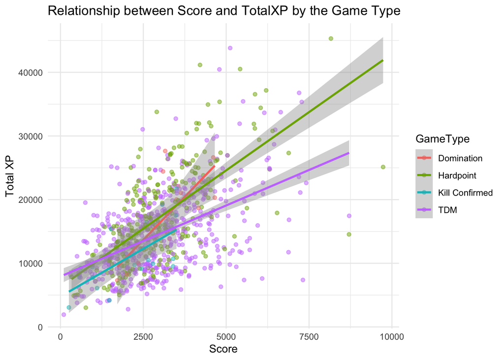

```r
library(ggplot2)
# Visualize the relationship between Score and TotalXP with color by GameType
ggplot(analysisDF, aes(x = Score, y = TotalXP, color = GameType)) +
  geom_point(alpha = 0.5) +
  geom_smooth(method = "lm", se = TRUE) +
  labs(title = "Relationship between Score and TotalXP by the Game Type",
       x = "Score", y = "Total XP") +
  theme_minimal()
```

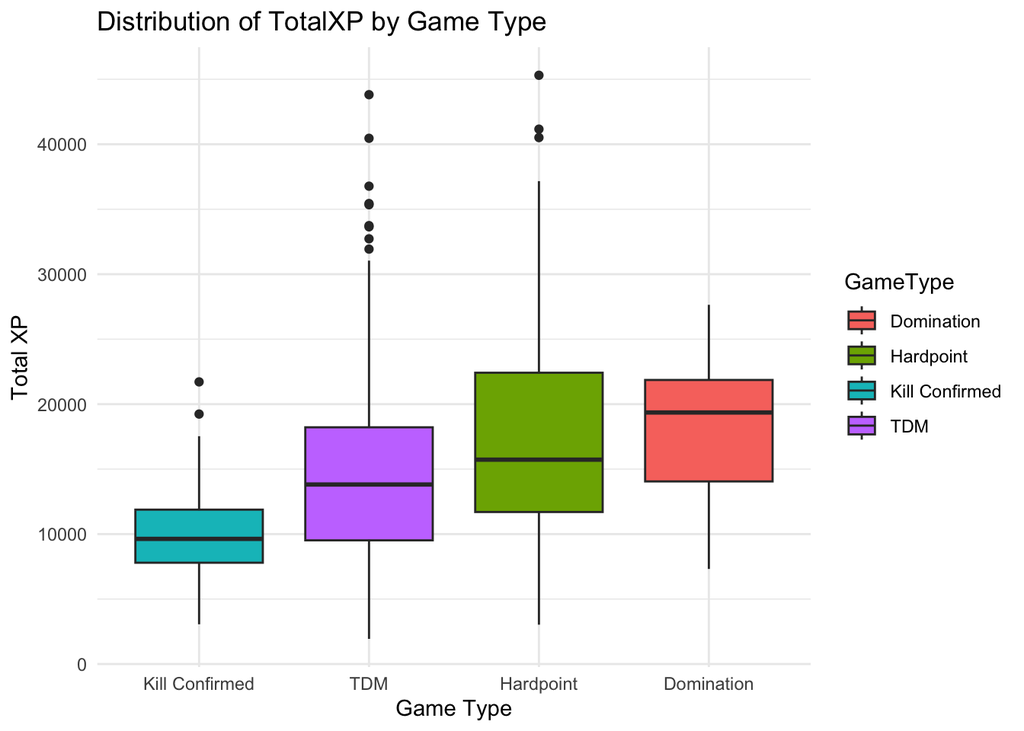

```r
# Create boxplots of TotalXP by GameType
ggplot(analysisDF, aes(x = reorder(GameType, TotalXP, FUN = median), y = TotalXP, fill = GameType)) +
  geom_boxplot() +
  labs(title = "Distribution of TotalXP by Game Type",
       x = "Game Type", y = "Total XP") +
  theme_minimal()
```

```r
# Build a linear regression model with interaction terms
model <- lm(TotalXP ~ Score * GameType, data = analysisDF)


summary(model)
```

```
##
## Call:
## lm(formula = TotalXP ~ Score * GameType, data = analysisDF)
##
## Residuals:
##      Min       1Q   Median       3Q      Max
## -23620.1  -4130.1   -152.2   3626.4  24467.6
##
## Coefficients:
##                              Estimate Std. Error t value Pr(>|t|)
## (Intercept)                   141.168   6140.010   0.023  0.98166
## Score                           5.413      1.805   2.999  0.00279 **
## GameTypeHardpoint            6153.288   6198.660   0.993  0.32117
## GameTypeKill Confirmed       4637.698   6695.983   0.693  0.48876
## GameTypeTDM                  7788.913   6167.196   1.263  0.20697
## Score:GameTypeHardpoint        -1.752      1.823  -0.961  0.33680
## Score:GameTypeKill Confirmed   -2.412      2.155  -1.119  0.26344
## Score:GameTypeTDM              -3.182      1.813  -1.755  0.07961 .
## ---
## Signif. codes:  0 '***' 0.001 '**' 0.01 '*' 0.05 '.' 0.1 ' ' 1
##
## Residual standard error: 5615 on 800 degrees of freedom
## Multiple R-squared:  0.3568, Adjusted R-squared:  0.3512
## F-statistic: 63.41 on 7 and 800 DF,  p-value: < 2.2e-16
```

```r
# Create a new dataframe for predictions with fixed Score values
scoreRange <- seq(min(analysisDF$Score), max(analysisDF$Score), length.out = 100)
gameTypes <- unique(analysisDF$GameType)
predDF <- expand.grid(Score = scoreRange, GameType = gameTypes)

# Generate predictions
predDF$PredictedXP <- predict(model, newdata = predDF)
```

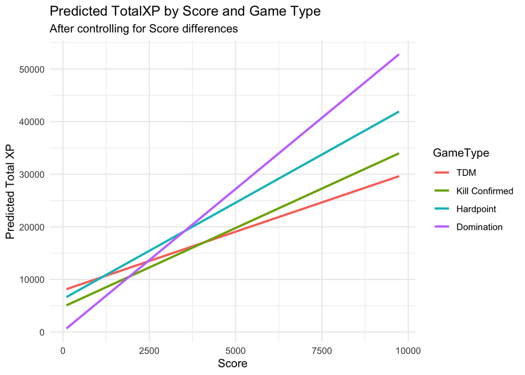

```r
# Visualize the model predictions
ggplot(predDF, aes(x = Score, y = PredictedXP, color = GameType)) +
  geom_line(size = 1) +
  labs(title = "Predicted TotalXP by Score and Game Type",
       subtitle = "After controlling for Score differences",
       x = "Score", y = "Predicted Total XP") +
  theme_minimal()
```

```r
# Calculate ANOVA to test if GameType has a significant effect
anovaResult <- anova(model)
print(anovaResult)
```

```
## Analysis of Variance Table
##
## Response: TotalXP
##                 Df     Sum Sq    Mean Sq  F value    Pr(>F)
## Score            1 1.1881e+10 1.1881e+10 376.8487 < 2.2e-16 ***
## GameType         3 1.3630e+09 4.5434e+08  14.4111 3.762e-09 ***
## Score:GameType   3 7.4902e+08 2.4967e+08   7.9194 3.290e-05 ***
## Residuals      800 2.5222e+10 3.1527e+07
## ---
## Signif. codes:  0 '***' 0.001 '**' 0.01 '*' 0.05 '.' 0.1 ' ' 1
```

## Task 3 Discussion

One thing that surprised me was how Score alone didn’t fully explain XP variation. Initially, I assumed a higher score would always translate to proportionally higher XP, regardless of mode. But the model and plots clearly showed that two players with similar scores could earn very different amounts of XP just because they played different game types. This could have practical implications for players trying to level up quickly: choosing certain game modes might be a more efficient way to earn XP, especially if they’re able to perform well in them.

That said, the analysis wasn’t without its challenges. Cleaning the game type data took more effort than expected, especially handling “HC” prefixes and inconsistent naming. Also, working with interaction terms in the regression model was conceptually challenging at first understanding what it means for the effect of score to vary depending on game type took some trial and error, and plotting the predicted XP values really helped bring that concept to life.

Overall, this task was a great exercise in cleaning messy data, exploring patterns visually, and building interpretable models to answer real questions the kind of work that mirrors practical data science problems.

# Task 4

Relevant Information: In this task, your goal is to compare a variety of classification methods. In particular, you should write your own research question that can be answered by comparing the effectiveness of various classification methodologies. To demonstrate your understanding of these methods, you should implement two classification methods from class, one of which must be random forest, and a third method that we will not cover in class. (The purpose of the using a method we did not cover is I want you to practice learning about a method and its implementation on your own. Basically, find a tutorial that explains the method and how to implement it.) You will then have to compare the results and decide which method was the most effective.

## Research Question: Write your own question and be sure that the question and answer are clearly written in your report.

Notes: Since you will be using random forest, do not use a decision/classification tree as one of your other methods. For this problem, you should provide a brief description of the methods that you will use. (A description is more than listing the name of the procedure. You should describe how the procedure works.) You will implement and compare the effectiveness of these methods. As part of this process, you will have to make a number of decisions such as whether you will do any data wrangling (maybe you remove partial matches, maybe you create new variables, etc.), which methods will you use, how will you fairly compare the results between methods, which method is best etc. All of these decisions should be included in your report. If I have to learn about your decisions/analysis by reading your code, you will lose points.

NOTE1: You will make your life easier if you pick a response with a small number of levels.

NOTE2: As you are picking a method that we did not cover, one way to find techniques is by looking at the textbook that we have been covering: An Introduction to Statistical Learning with Applications in R by Gareth James et al. You can find a pdf of the textbook on the author’s site: https://www.statlearning.com/.

## Approach

To keep the evaluation consistent, I used 5-fold cross-validation with the ROC AUC metric as the baseline for tuning. After training, I assessed all three models on the test set using accuracy, precision, recall, and F1 score. I also plotted ROC curves and reviewed feature importance to interpret each model’s behavior. Throughout the process, I tried to make sure every comparison was fair: same preprocessing, same features, same evaluation metrics — to truly judge which model performed best.

```r
# --- 0. Load Necessary Libraries ---
library(dplyr)
library(caret)
library(randomForest)
library(e1071)  # For SVM

library(kernlab) # For SVM
library(xgboost) # For XGBoost (third method)
```

```r
library(ROCR)    # For ROC curves
library(ggplot2)

# --- 1. Data Preparation ---
# Convert Result to a binary outcome (Win/Loss)
votesDF <- votesDF %>%
  mutate(Result = as.character(Result)) %>%
  mutate(Result = trimws(Result)) %>%
  filter(Result != "" & !is.na(Result)) %>%
  # Convert to binary classification
  mutate(Result = ifelse(grepl("^W|^w|^1", Result), "Win", "Loss")) %>%
  mutate(Result = as.factor(Result))

# Create feature engineering function
createFeatures <- function(df) {
  df %>%
    # Create KD Ratio (handle division by zero)
    mutate(KDRatio = ifelse(Deaths == 0, Eliminations, Eliminations/Deaths)) %>%
    # Create Score Per Minute
    mutate(ScorePerMinute = ifelse(Time_Min == 0, Score, Score/Time_Min)) %>%
    # Create Damage Per Elimination
    mutate(DamagePerElim = ifelse(Eliminations == 0, Damage, Damage/Eliminations))
}

# Apply feature engineering
modelDF <- votesDF %>%
  createFeatures() %>%
  select(Result, Score, Eliminations, Deaths, Damage, GameType,
         Map1, Map2, Choice, TotalXP, KDRatio, ScorePerMinute, DamagePerElim) %>%
  # Convert categorical variables to factors
  mutate(
    GameType = as.factor(GameType),
    Map1 = as.factor(Map1),
    Map2 = as.factor(Map2),
    Choice = as.factor(Choice)
  ) %>%
  # Remove rows with NA values
  na.omit()

# Check data structure
str(modelDF)
```

```
## 'data.frame':    253 obs. of  13 variables:
##  $ Result        : Factor w/ 2 levels "Loss","Win": 1 1 1 1 1 1 2 1 1 2 ...
##  $ Score         : int  2025 2045 1550 1760 3260 1240 2615 4955 3000 2125 ...
##  $ Eliminations  : int  14 13 7 10 19 7 22 39 20 17 ...
##  $ Deaths        : int  34 42 17 15 26 18 20 32 20 27 ...
##  $ Damage        : int  392 359 192 224 502 195 618 789 2597 2432 ...
##  $ GameType      : Factor w/ 8 levels "Domination","Hardpoint",..: 4 4 4 4 4 4 4 4 2 2 ...
##  $ Map1          : Factor w/ 29 levels "","amerika","apocalypse",..: 1 29 1 24 24 1 2 1 28 23 ...
##   ..- attr(*, "names")= chr [1:253] "" "zoo" "" "slums" ...
##  $ Map2          : Factor w/ 29 levels "","amerika","apocalypse",..: 1 3 1 8 11 1 8 1 18 26 ...
##   ..- attr(*, "names")= chr [1:253] "" "apocalypse" "" "crossroads strike" ...
##  $ Choice        : Factor w/ 29 levels "","amerika","apocalypse",..: 18 29 20 8 24 7 8 10 28 23 ...
##   ..- attr(*, "names")= chr [1:253] "miami strike" "zoo" "nuketown '84" "crossroads strike" ...
##  $ TotalXP       : int  10419 8468 8465 5438 11806 10995 7200 12240 15991 13903 ...
##  $ KDRatio       : num  0.412 0.31 0.412 0.667 0.731 ...
##  $ ScorePerMinute: num  2025 1022 775 880 1630 ...
##  $ DamagePerElim : num  28 27.6 27.4 22.4 26.4 ...
##  - attr(*, "na.action")= 'omit' Named int [1:555] 1 2 3 4 5 6 7 8 9 10 ...
##   ..- attr(*, "names")= chr [1:555] "1" "2" "3" "4" ...
```

```r
table(modelDF$Result)
```

```
##
## Loss  Win
##  202   51
```

```r
# --- 2. Data Splitting ---
set.seed(123)
trainIndex <- createDataPartition(modelDF$Result, p = 0.7, list = FALSE, times = 1)
trainData <- modelDF[trainIndex, ]
testData <- modelDF[-trainIndex, ]

# --- 3. Model Training Setup ---
# Set up cross-validation for binary classification
ctrl <- trainControl(
  method = "cv",
  number = 5,
  classProbs = TRUE,
  summaryFunction = twoClassSummary,
  savePredictions = "final",
  sampling = "down" # Use down-sampling to handle class imbalance
)

# --- 4. Model Training ---
# Model 1: Random Forest
cat("Training Random Forest model...\n")
```

```
## Training Random Forest model...
```

```r
rfModel <- train(
  Result ~ .,
  data = trainData,
  method = "rf",
  trControl = ctrl,
  metric = "ROC",
  importance = TRUE
)

# Model 2: Logistic Regression
cat("Training Logistic Regression model...\n")
```

```
## Training Logistic Regression model...
```

```r
logModel <- train(
  Result ~ .,
  data = trainData,
  method = "glm",
  family = "binomial",
  trControl = ctrl,
  metric = "ROC"
)
# Model 3: XGBoost (not covered in class)
cat("Training XGBoost model...\n")
```

```
## Training XGBoost model...
```

```r
xgbModel <- train(
  Result ~ .,
  data = trainData,
  method = "xgbTree",
  trControl = ctrl,
  metric = "ROC",
  verbosity = 0
)

# --- 5. Model Comparison ---
# Compare models using resamples
modelList <- list(
  RandomForest = rfModel,
  LogisticRegression = logModel,
  XGBoost = xgbModel
)

# Compare models using resamples
modelComparison <- resamples(modelList)
summary(modelComparison)
```

```
##
## Call:
## summary.resamples(object = modelComparison)
##
## Models: RandomForest, LogisticRegression, XGBoost
## Number of resamples: 5
##
## ROC
##                         Min.   1st Qu.    Median      Mean   3rd Qu.      Max.
## RandomForest       0.6853448 0.6862245 0.7290640 0.7629838 0.8469388 0.8673469
## LogisticRegression 0.3698980 0.5492611 0.5517241 0.5320593 0.5867347 0.6026786
## XGBoost            0.5969388 0.7193878 0.7684729 0.7475545 0.8060345 0.8469388
##                    NA's
## RandomForest          0
## LogisticRegression    0
## XGBoost               0
##
## Sens
##                         Min.   1st Qu.    Median      Mean   3rd Qu.      Max.
## RandomForest       0.5862069 0.6071429 0.6071429 0.6413793 0.6206897 0.7857143
## LogisticRegression 0.3571429 0.5000000 0.5172414 0.5280788 0.5517241 0.7142857
## XGBoost            0.5000000 0.5714286 0.5862069 0.6334975 0.7241379 0.7857143
##                    NA's
## RandomForest          0
## LogisticRegression    0
## XGBoost               0
##
## Spec
##                         Min.   1st Qu.    Median      Mean   3rd Qu.      Max.
## RandomForest       0.5714286 0.6250000 0.8571429 0.7821429 0.8571429 1.0000000
## LogisticRegression 0.2857143 0.5714286 0.5714286 0.5785714 0.7142857 0.7500000
## XGBoost            0.7142857 0.7142857 0.7500000 0.7785714 0.8571429 0.8571429
##                    NA's
## RandomForest          0
## LogisticRegression    0
## XGBoost               0
```

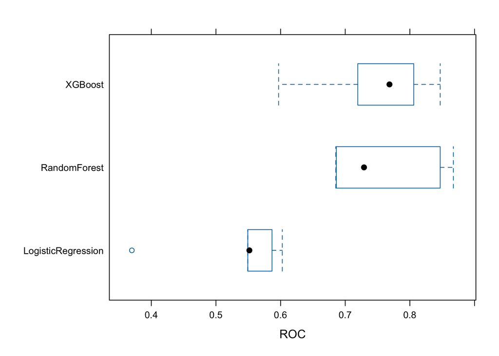

```r
# Create comparison plot
bwplot(modelComparison, metric = "ROC")
```

```
## RandomForest AUC: 0.6156
```

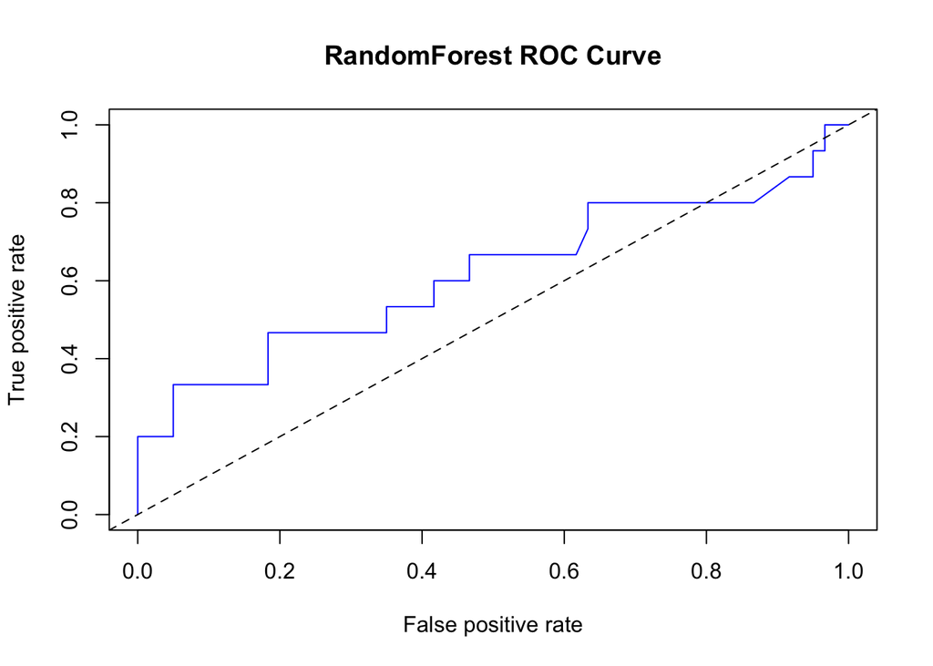

```
## LogisticRegression AUC: 0.4417
```

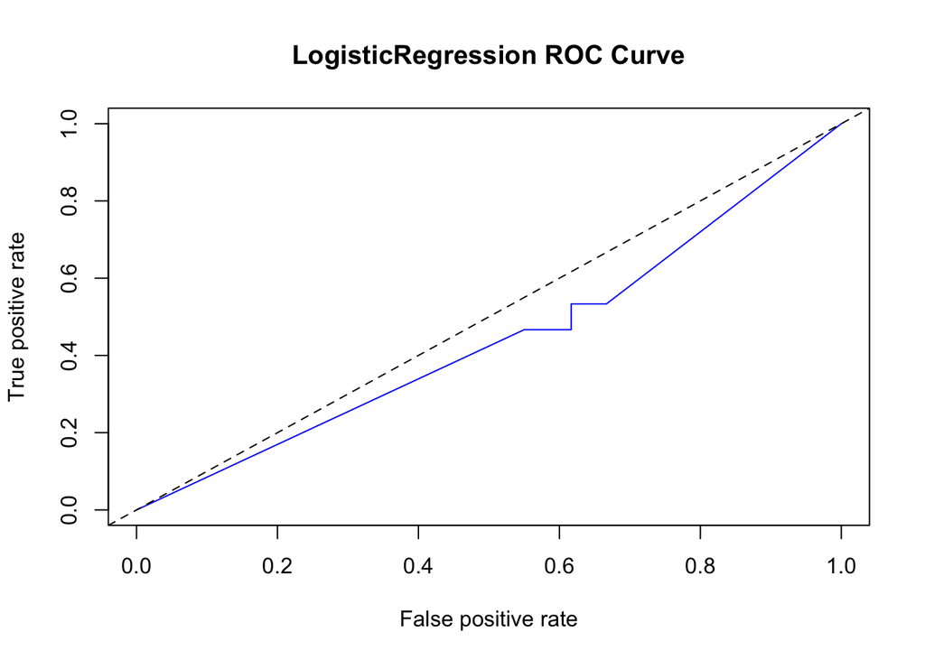

```
## XGBoost AUC: 0.6478
```

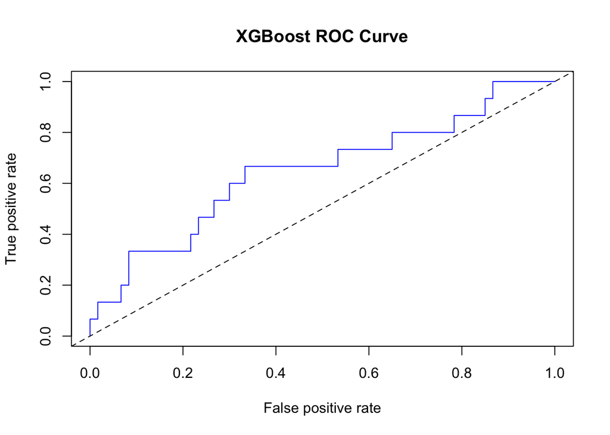

```r
# --- 6. Model Evaluation on Test Set ---
# Function to calculate metrics
calculateMetrics <- function(pred, actual, model_name) {
  cm <- confusionMatrix(pred, actual, positive = "Win")

  # Extract metrics
  accuracy <- cm$overall["Accuracy"]
  precision <- cm$byClass["Pos Pred Value"]
  recall <- cm$byClass["Sensitivity"]
  f1 <- cm$byClass["F1"]

  # Return as data frame row
  data.frame(
    Model = model_name,
    Accuracy = accuracy,
    Precision = precision,
    Recall = recall,
    F1Score = f1,
    stringsAsFactors = FALSE
  )
}

# Evaluate all models
allMetrics <- data.frame()

for (name in names(modelList)) {
  model <- modelList[[name]]
  predictions <- predict(model, testData)
  predProbs <- predict(model, testData, type = "prob")

  # Calculate metrics
  metrics <- calculateMetrics(predictions, testData$Result, name)
  allMetrics <- rbind(allMetrics, metrics)

  # Create ROC curve
  pred <- prediction(predProbs$Win, testData$Result == "Win")
  perf <- performance(pred, "tpr", "fpr")
  auc <- performance(pred, "auc")@y.values[[1]]

  # Print AUC
  cat(name, "AUC:", round(auc, 4), "\n")

  # Plot ROC curve
  plot(perf, main = paste(name, "ROC Curve"), col = "blue")
  abline(0, 1, lty = 2)
}
```

```r
# Display metrics
print(allMetrics)
```

```
##                        Model  Accuracy Precision    Recall   F1Score
## Accuracy        RandomForest 0.6266667 0.2592593 0.4666667 0.3333333
## Accuracy1 LogisticRegression 0.4000000 0.1739130 0.5333333 0.2622951
## Accuracy2            XGBoost 0.6533333 0.3225806 0.6666667 0.4347826
```

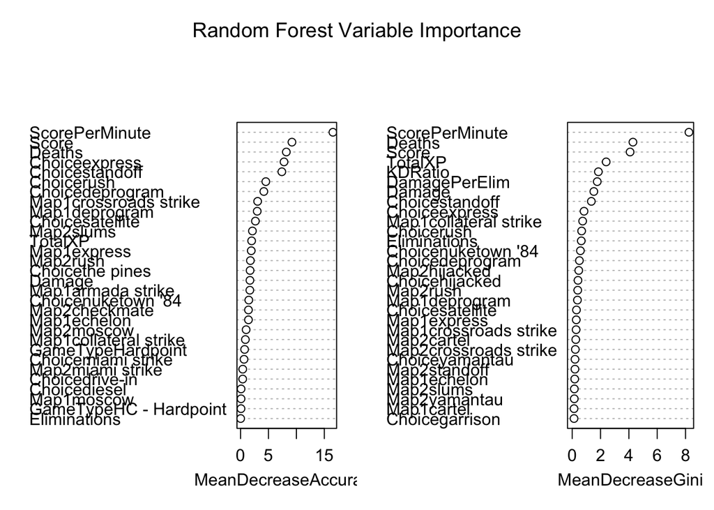

```
##                                                 Feature  Importance
## ScorePerMinute                           ScorePerMinute 8.239413574
## Deaths                                           Deaths 4.287016508
## Score                                             Score 4.086372701
## TotalXP                                         TotalXP 2.397538232
## KDRatio                                         KDRatio 1.848343312
## DamagePerElim                             DamagePerElim 1.768019135
## Damage                                           Damage 1.527765850
## Choicestandoff                           Choicestandoff 1.351275549
## Choiceexpress                             Choiceexpress 0.835439958
## Map1collateral strike             Map1collateral strike 0.737605080
## Choicerush                                   Choicerush 0.665801863
## Eliminations                               Eliminations 0.641900256
## Choicenuketown '84                   Choicenuketown '84 0.579275231
## Choicedeprogram                         Choicedeprogram 0.507919075
## Map2hijacked                               Map2hijacked 0.463323949
## Choicehijacked                           Choicehijacked 0.408527463
## Map2rush                                       Map2rush 0.391110184
## Map1deprogram                             Map1deprogram 0.370671633
## Choicesatellite                         Choicesatellite 0.301662244
## Map1express                                 Map1express 0.286859626
## Map1crossroads strike             Map1crossroads strike 0.277710586
## Map2cartel                                   Map2cartel 0.251556778
## Map2crossroads strike             Map2crossroads strike 0.221219786
## Choiceyamantau                           Choiceyamantau 0.197782330
## Map2standoff                               Map2standoff 0.194409391
## Map1echelon                                 Map1echelon 0.178113963
## Map2slums                                     Map2slums 0.152205962
## Map2yamantau                               Map2yamantau 0.147128131
## Map1cartel                                   Map1cartel 0.130693797
## Choicegarrison                           Choicegarrison 0.129141916
## Map2diesel                                   Map2diesel 0.109412369
## Map1hijacked                               Map1hijacked 0.100127900
## Choicemiami strike                   Choicemiami strike 0.090488821
## Map2miami strike                       Map2miami strike 0.081835801
## Choicezoo                                     Choicezoo 0.080864289
## Map1armada strike                     Map1armada strike 0.078399456
## Map2the pines                             Map2the pines 0.076758557
## Map1moscow                                   Map1moscow 0.075409848
## Map2checkmate                             Map2checkmate 0.070752990
```

[output cut: 45 more lines]

```
## GameTypeKill Confirmed           GameTypeKill Confirmed 0.000000000
## GameTypeTDM                                 GameTypeTDM 0.000000000
## Map1jungle                                   Map1jungle 0.000000000
## Map1miami                                     Map1miami 0.000000000
## Map1wmd                                         Map1wmd 0.000000000
## Map2apocalypse                           Map2apocalypse 0.000000000
## Map2collateral strike             Map2collateral strike 0.000000000
## Map2drive-in                               Map2drive-in 0.000000000
## Map2jungle                                   Map2jungle 0.000000000
## Map2miami                                     Map2miami 0.000000000
## Map2wmd                                         Map2wmd 0.000000000
## Choicecollateral strike         Choicecollateral strike 0.000000000
## Choicejungle                               Choicejungle 0.000000000
## Choicemiami                                 Choicemiami 0.000000000
## Choicewmd                                     Choicewmd 0.000000000
```

```r
# --- 7. Feature Importance ---
# For Random Forest
if (!is.null(rfModel$finalModel)) {
  varImpPlot(rfModel$finalModel, main = "Random Forest Variable Importance")

  # Get variable importance as data frame
  varImp <- importance(rfModel$finalModel)
  varImpDF <- data.frame(
    Feature = rownames(varImp),
    Importance = varImp[, "MeanDecreaseGini"]
  )
  varImpDF <- varImpDF[order(varImpDF$Importance, decreasing = TRUE), ]
  print(varImpDF)
}
```

```r
# For Logistic Regression
if (!is.null(logModel$finalModel)) {
  # Extract coefficients
  coefs <- coef(logModel$finalModel)
  coefDF <- data.frame(
    Feature = names(coefs),
    Coefficient = as.numeric(coefs)
  )
  coefDF <- coefDF[order(abs(coefDF$Coefficient), decreasing = TRUE), ]
  print(coefDF)
}
```

```
##                           Feature   Coefficient
## 35                      Map1slums  4.035486e+02
## 31             `Map1nuketown '84` -3.863830e+02
## 49                     Map2diesel -3.760784e+02
## 91                    Choiceslums -3.646902e+02
## 25                   Map1garrison  3.540912e+02
## 64                   Map2standoff  2.818197e+02
## 93              `Choicethe pines` -2.734141e+02
## 58                     Map2moscow -2.713328e+02
## 40                        Map1zoo -2.710955e+02
## 54                   Map2hijacked -2.519340e+02
## 57             `Map2miami strike` -2.504146e+02
## 16                     Map1cartel  2.402823e+02
## 1                     (Intercept) -2.381962e+02
## 90                Choicesatellite -2.313924e+02
```

[output cut: 86 more lines]

```r
# For XGBoost
if (!is.null(xgbModel$finalModel)) {
  # Get feature importance
  importance <- xgb.importance(model = xgbModel$finalModel)
  print(importance)
}
```

```
##              Feature         Gain       Cover   Frequency
##               <char>        <num>       <num>       <num>
## 1:    ScorePerMinute 0.2600923294 0.209130172 0.191222571
## 2:           TotalXP 0.1582429650 0.129781580 0.137931034
## 3:            Deaths 0.1344159604 0.135023497 0.125391850
## 4:           KDRatio 0.1334234136 0.137208032 0.137931034
## 5:             Score 0.0861702745 0.093667103 0.094043887
## 6:            Damage 0.0773232815 0.114846627 0.119122257
## 7:      Eliminations 0.0750902715 0.078024329 0.078369906
## 8:     DamagePerElim 0.0748381440 0.099805284 0.112852665
## 9: GameTypeHardpoint 0.0004033602 0.002513377 0.003134796
```

```r
# --- 8. Determine Best Model ---
bestModel <- allMetrics$Model[which.max(allMetrics$F1Score)]
cat("The best performing model based on F1 Score is:", bestModel, "\n")
```

```
## The best performing model based on F1 Score is: XGBoost
```

```r
# --- 9. Model Description ---
cat("\n--- Model Descriptions ---\n")
```

```
##
## --- Model Descriptions ---
```

```r
cat("1. Random Forest:\n")
```

```
## 1. Random Forest:
```

```r
cat("   Random Forest is an ensemble learning method that builds multiple decision trees during training\n")
```

```
##    Random Forest is an ensemble learning method that builds multiple decision trees during training
```

```r
cat("   and outputs the class that is the mode of the classes of individual trees. It reduces overfitting\n")
```

```
##    and outputs the class that is the mode of the classes of individual trees. It reduces overfitting
```

```r
cat("   by creating trees from bootstrapped samples and randomly selecting a subset of features at each split.\n\n")
```

```
##    by creating trees from bootstrapped samples and randomly selecting a subset of features at each split.
```

```r
cat("2. Logistic Regression:\n")
```

```
## 2. Logistic Regression:
```

```r
cat("   Logistic Regression is a statistical model that uses a logistic function to model a binary dependent\n")
```

```
##    Logistic Regression is a statistical model that uses a logistic function to model a binary dependent
```

```r
cat("   variable. It estimates the probability of a binary outcome based on one or more predictor variables.\n")
```

```
##    variable. It estimates the probability of a binary outcome based on one or more predictor variables.
```

```r
cat("   It's simple, interpretable, and provides insights into feature importance through coefficients.\n\n")
```

```
##    It's simple, interpretable, and provides insights into feature importance through coefficients.
```

```r
cat("3. XGBoost (eXtreme Gradient Boosting):\n")
```

```
## 3. XGBoost (eXtreme Gradient Boosting):
```

```r
cat("   XGBoost is an optimized gradient boosting implementation that builds trees sequentially, with each\n")
```

```
##    XGBoost is an optimized gradient boosting implementation that builds trees sequentially, with each
```

```r
cat("   tree correcting the errors of the previous ones. It uses gradient descent to minimize loss and includes\n")
```

```
##    tree correcting the errors of the previous ones. It uses gradient descent to minimize loss and includes
```

```r
cat("   regularization to prevent overfitting. XGBoost is known for its speed and performance in competitions.\n")
```

```
##    regularization to prevent overfitting. XGBoost is known for its speed and performance in competitions.
```

```r
# ---- 10. Confusion Matrix ---- #
# --- Confusion Matrices for All Models ---
library(dplyr)
library(caret)
library(randomForest)
library(e1071)  # For SVM

library(kernlab) # For SVM
library(xgboost) # For XGBoost (third method)
library(ROCR)    # For ROC curves
library(ggplot2)

# Function to print confusion matrix
print_conf_matrix <- function(model, model_name, testData) {
  cat("\nConfusion Matrix for", model_name, ":\n")
  preds <- predict(model, newdata = testData)
  cm <- confusionMatrix(preds, testData$Result, positive = "Win")
  print(cm)
}

# Run for each model
print_conf_matrix(rfModel, "Random Forest", testData)
```

```
##
## Confusion Matrix for Random Forest :
## Confusion Matrix and Statistics
##
##           Reference
## Prediction Loss Win
##       Loss   40   8
##       Win    20   7
##
##                Accuracy : 0.6267
##                  95% CI : (0.5073, 0.7357)
##     No Information Rate : 0.8
##     P-Value [Acc > NIR] : 0.99985
##
##                   Kappa : 0.1026
##
##  Mcnemar's Test P-Value : 0.03764
##
##             Sensitivity : 0.46667
##             Specificity : 0.66667
##          Pos Pred Value : 0.25926
##          Neg Pred Value : 0.83333
##              Prevalence : 0.20000
##          Detection Rate : 0.09333
##    Detection Prevalence : 0.36000
##       Balanced Accuracy : 0.56667
##
##        'Positive' Class : Win
##
```

```r
print_conf_matrix(logModel, "Logistic Regression", testData)
```

```
##
## Confusion Matrix for Logistic Regression :
```

```
## Confusion Matrix and Statistics
##
##           Reference
## Prediction Loss Win
##       Loss   22   7
##       Win    38   8
##
##                Accuracy : 0.4
##                  95% CI : (0.2885, 0.5196)
##     No Information Rate : 0.8
##     P-Value [Acc > NIR] : 1
##
##                   Kappa : -0.0563
##
##  Mcnemar's Test P-Value : 7.744e-06
##
##             Sensitivity : 0.5333
##             Specificity : 0.3667
##          Pos Pred Value : 0.1739
##          Neg Pred Value : 0.7586
##              Prevalence : 0.2000
##          Detection Rate : 0.1067
##    Detection Prevalence : 0.6133
##       Balanced Accuracy : 0.4500
##
##        'Positive' Class : Win
##
```

```r
print_conf_matrix(xgbModel, "XGBoost", testData)
```

```
##
## Confusion Matrix for XGBoost :
## Confusion Matrix and Statistics
##
##           Reference
## Prediction Loss Win
##       Loss   39   5
##       Win    21  10
##
##                Accuracy : 0.6533
##                  95% CI : (0.5346, 0.7596)
##     No Information Rate : 0.8
##     P-Value [Acc > NIR] : 0.999063
##
##                   Kappa : 0.2262
##
##  Mcnemar's Test P-Value : 0.003264
##
##             Sensitivity : 0.6667
##             Specificity : 0.6500
##          Pos Pred Value : 0.3226
##          Neg Pred Value : 0.8864
##              Prevalence : 0.2000
##          Detection Rate : 0.1333
##    Detection Prevalence : 0.4133
##       Balanced Accuracy : 0.6583
##
##        'Positive' Class : Win
##
```

# Discussion:

Overall, this task gave me a deeper appreciation for model evaluation, cross-validation, and the trade-offs between interpretability and predictive power. Each method had its own strengths: Logistic Regression was fast and interpretable, Random Forest was reliable and robust, and XGBoost was powerful (though a bit of a black box).